# Getting normally distributed data

First checking to see which datasets likeley come from a normal distribution. Sequencing data is definitely not normally distributed, since they are counts.

[figure not shown]

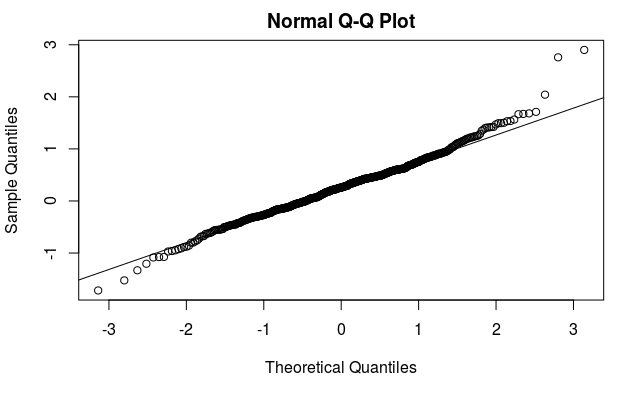

```r
qqnorm(data);qqline(data)
```

```r
shapiro.test(data)
```

```
    Shapiro-Wilk normality test

data:  data
W = 0.98507, p-value = 9.758e-06
```

Based on the Shapiro-Wilk normality test, we can reject the null hypothesis that this example sample comes from a normal distribution. I could do this test for every dataset, however, I would probably find that all the data is not normally distributed.

```r
for(d in names(diseases)){
  obj <- get(sprintf("%s_miRNAseq", d))
  assign(sprintf("%s_miRNAseq2", d), obj[,seq(from = 2, to = ncol(obj), by = 3)])
}
```

```r
for(d in names(diseases)){
  assign(sprintf("%s_miRNAseq", d), get(sprintf("%s_miRNAseq2", d)))
}
```

CNV data is also in some sort of log2 transformed form, with the addition that 2 is subtracted from all values so that a value of 0 means no change from the normal copy number of 2. This means all data is already transformed to get it as close as possible to a normal distribution.

Some rows are completely filled with NA’s. To correct this:

```r
for(d in names(diseases)){
  for(o in omics){
    objname <- sprintf("%s_%s", d, o)
    print(objname)
    if(exists(objname)){
      obj <- get(objname)
      assign(objname, obj[complete.cases(obj),])
    }
  }
}
```

```
[1] "BRCA_mRNA"
[1] "BRCA_mRNAseq"
[1] "BRCA_miRNA"
[1] "BRCA_miRNAseq"
[1] "BRCA_CNV"
[1] "BRCA_methylation"
[1] "GBM_mRNA"
[1] "GBM_mRNAseq"
[1] "GBM_miRNA"
[1] "GBM_miRNAseq"
[1] "GBM_CNV"
[1] "GBM_methylation"
[1] "OV_mRNA"
[1] "OV_mRNAseq"
[1] "OV_miRNA"
[1] "OV_miRNAseq"
[1] "OV_CNV"
[1] "OV_methylation"
[1] "PRAD_mRNA"
[1] "PRAD_mRNAseq"
[1] "PRAD_miRNA"
[1] "PRAD_miRNAseq"
[1] "PRAD_CNV"
[1] "PRAD_methylation"
```

Now we can impute missing values:

```r
# biocLite("impute")
library(impute)
```

```r
for(d in names(diseases)){
  for(o in omics[-5]){
    objname <- sprintf("%s_%s", d, o)
    if(exists(objname)){
      obj <- get(objname)
      assign(objname, obj[complete.cases(obj),])
      print(d)
      print(o)
      assign(
        sprintf("%s_%s_imputed", d, o),
        impute.knn(obj),
        envir = .GlobalEnv
      )
    }
  }
}
```

```r
for(d in names(diseases)){
  for(o in omics[-5]){
    if(exists(sprintf("%s_%s_imputed", d, o))){
      assign(sprintf("%s_%s", d, o), get(sprintf("%s_%s_imputed", d, o))$data)
    }
  }
}
```

```r
rownames(BRCA_pheno) <- unlist(lapply(strsplit(rownames(BRCA_pheno), split = "[-]"), vpaste0, collapse = "."))
```

```
Error in match.fun(FUN) : object 'vpaste0' not found
```

```r
# library("sva")
for(d in names(diseases)){
  print(d)
  assign(sprintf("%s_mRNA_corrected", d), CorrectBatch(
    get(sprintf("%s_mRNA", d)),
    get(sprintf("%s_mRNA_patients", d)),
    get(sprintf("%s_pheno", d))
  ))
}
```

```r
for(d in names(diseases)){
  if(exists(sprintf("%s_mRNA_corrected", d))){
    assign(sprintf("%s_mRNA", d), get(sprintf("%s_mRNA_corrected", d)))
  }
}
```

And now save everything:

```r
for(d in names(diseases)){
  print(d)
  if(exists(sprintf("%s_pheno", d))){
    save(list = sprintf("%s_pheno", d),
         file = sprintf("/home/abidata/Joanna/%s/%s_pheno.rda", d, d))
  }
  for(o in omics){
    print(o)
    if(exists(sprintf("%s_%s", d, o))){
      save(list = sprintf("%s_%s", d, o),
           file = sprintf("/home/abidata/Joanna/%s/%s/%s_%s.rda", d, o, d, o))
      save(list = sprintf("%s_%s_patients", d, o),
           file = sprintf("/home/abidata/Joanna/%s/%s/%s_%s_patients.rda", d, o, d, o))
    }
  }
}
```

```
[1] "BRCA"
[1] "mRNA"
[1] "mRNAseq"
[1] "miRNA"
[1] "miRNAseq"
[1] "CNV"
[1] "methylation"
[1] "GBM"
[1] "mRNA"
[1] "mRNAseq"
[1] "miRNA"
[1] "miRNAseq"
[1] "CNV"
[1] "methylation"
[1] "OV"
[1] "mRNA"
[1] "mRNAseq"
[1] "miRNA"
[1] "miRNAseq"
[1] "CNV"
[1] "methylation"
[1] "PRAD"
[1] "mRNA"
[1] "mRNAseq"
[1] "miRNA"
[1] "miRNAseq"
[1] "CNV"
[1] "methylation"
```